# LTEE hypoxia manuscript: approved five-figure plan

Gate A closed on July 24, 2026. This surface records the approved architecture, resolved corrections, evidence boundaries, and drafting scope. It contains no draft figures and authorizes no work beyond the explicit drafting boundary.

Gate A approved · Matched observations → model assumptions → in-vitro fit and mechanism → in-vivo fit and solution landscape → joint-fit context differences

**5**active main figures

**3**fit-quality openings in Figures 3–5

**1**figure explicitly deferred

**0**refits authorized

## 1. Existing Figures And Panels

The restored TeX defines six historical main-figure concepts. Five historical composites are embedded below only to make the requested changes concrete; Figure 2 is caption-only. These images are review context, not draft assets.

**Historical-use boundary.** Every accepted panel must later be regenerated from declared observations, exact fit tables or objects, and repository-local generator code. No historical raster pixels may enter a manuscript figure.

### Historical Figure 1

historical context

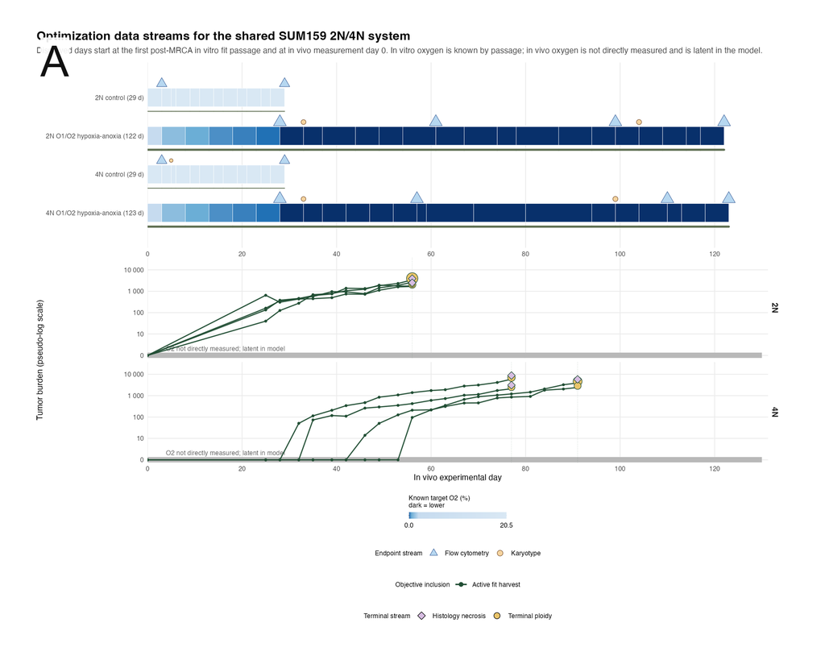

**Useful role:** A source-table-driven matched-lineage timeline.

**Main concern:** It shows design and sampling, but not the observed chromosome trajectories used to motivate the Results claim.

**Historical source:** commit `7e72dca88caf`; SHA-256 `fb1aad7ac0e263ee…`; 1696 × 1357 px.

`agent-dev/manuscript_work_packages/ltee_hypoxia_model/ideation/existing_context/assembled_fig1.png`

### Historical Figure 3

historical context

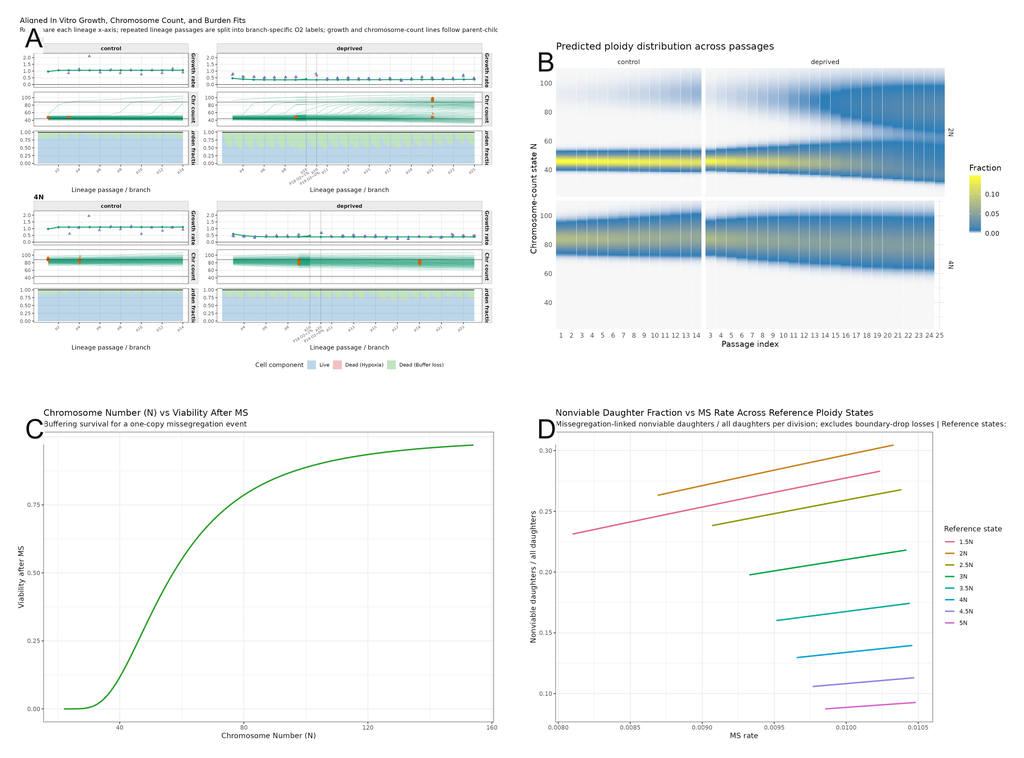

**Useful role:** Fit, predicted distribution, survival function, and mechanism diagnostics.

**Main concern:** Panel A is too composite. Its left-side control comparators are valid and should be retained, but the revised A should show growth rate over passage only. Figure 3E is rejected.

**Historical source:** commit `7e72dca88caf`; SHA-256 `7b2493a4a0af8831…`; 3392 × 2512 px.

`agent-dev/manuscript_work_packages/ltee_hypoxia_model/ideation/existing_context/assembled_fig3.png`

### Historical Figure 4

historical context

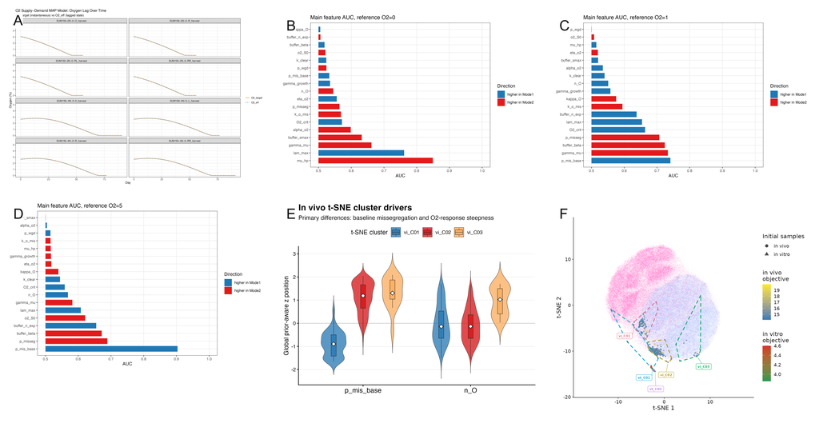

**Useful role:** Latent effective-O2 trajectories, AUC screens, and solution-landscape context.

**Main concern:** Panels A-E are in-vivo analyses, while panel F intentionally embeds both in-vivo and in-vitro fits. The pooled embedding must remain unchanged; AUCs should still be described as separators rather than causal effects.

**Historical source:** commit `7e72dca88caf`; SHA-256 `543fa971972dc22c…`; 5088 × 2705 px.

`agent-dev/manuscript_work_packages/ltee_hypoxia_model/ideation/existing_context/assembled_fig4.png`

### Historical Figure 5

historical context

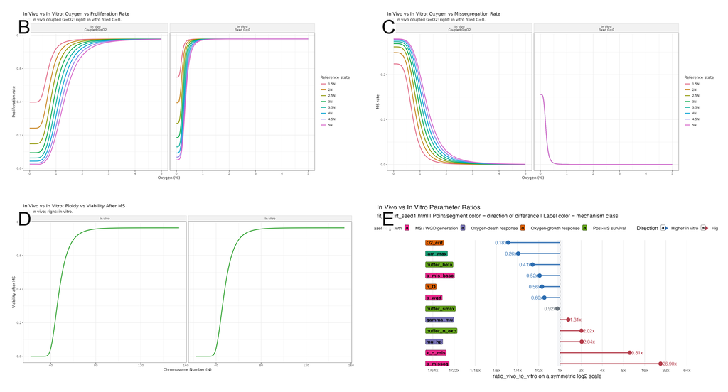

**Useful role:** Context-specific fitted functions and parameter-ratio context.

**Main concern:** Panels B-D and E came from incompatible joint runs. The revised figure must show fit adequacy first, retain a full all-six ratio view second, and regenerate the three functions from the same six winners.

**Historical source:** commit `7e72dca88caf`; SHA-256 `f48d4451bd21d8e3…`; 3392 × 1830 px.

`agent-dev/manuscript_work_packages/ltee_hypoxia_model/ideation/existing_context/assembled_fig5.png`

### Historical Figure 6

historical context

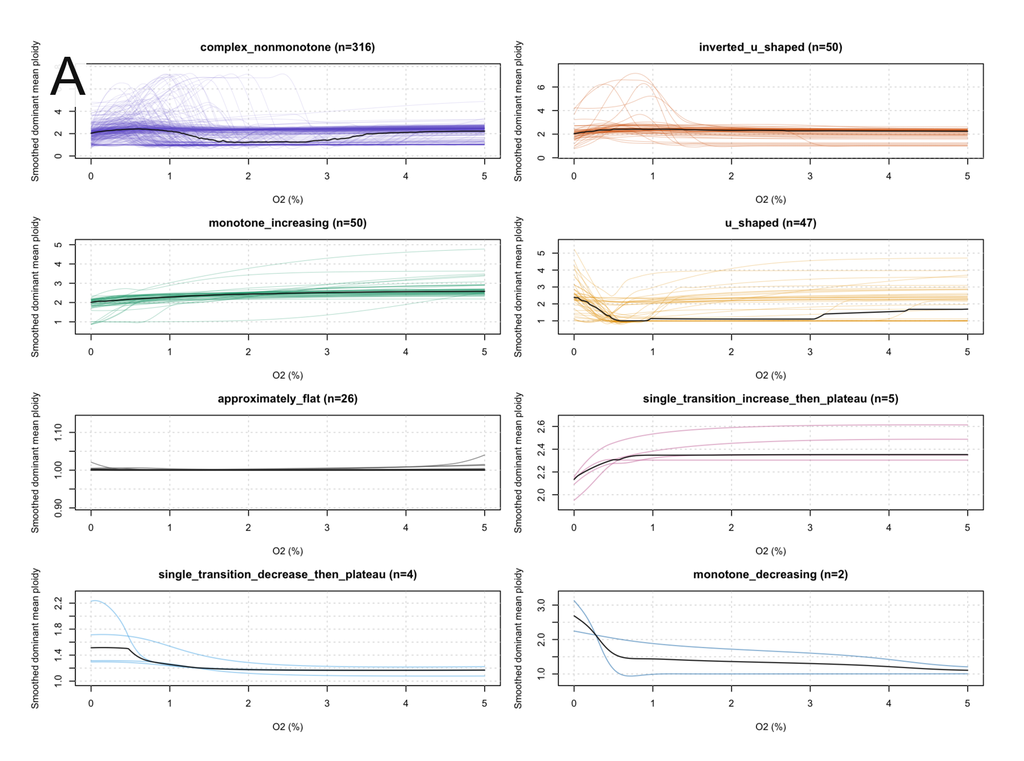

**Useful role:** Fixed-O2 response-curve classes.

**Main concern:** The user has deferred Figure 6, its framing, and its missing analytical map. It remains outside the approved five-figure drafting scope.

**Historical source:** commit `7e72dca88caf`; SHA-256 `a4a190bd20d4dc06…`; 1696 × 1260 px.

`agent-dev/manuscript_work_packages/ltee_hypoxia_model/ideation/existing_context/assembled_fig6.png`

### Figure 2

greenfield

No historical panel exists.  
The TeX contains only a five-part model-overview caption.

**Useful role:** One integrated schematic connecting resource context, growth/death cost, CIN/WGD generation, post-missegregation survival, and chromosome-state outcomes.

**Main concern:** It must show implemented model assumptions and mechanisms, not imply independent experimental proof.

### Restored TeX scaffold mapped to the revised proposal

| panel_id | current_caption_role | evidence_status | proposed_role | claim_guardrail |
| --- | --- | --- | --- | --- |
| F1A | Matched in-vitro and in-vivo timelines and measurements | available_requires_regeneration | Simplified matched design timeline | The design motivates comparison; it does not itself reveal selection. |
| F1B | Not currently specified | available_requires_replot | Observed in-vitro chromosome-number trajectory across informative passages | Describe measured change without assigning a fitted mechanism. |
| F1C | Not currently specified | available_requires_replot | Observed in-vivo starting and terminal chromosome-number distributions with compact harvest context | Do not imply longitudinal tumor karyotyping when only starting and terminal distributions are measured. |
| F2A | Resource limitation axis | greenfield | Context-specific resource input and latent state | Model assumption, not observed evidence. |
| F2B | High-ploidy growth and death cost | greenfield | Chromosome-number-dependent proliferation and death module | Model mechanism, not proof of a universal high-ploidy cost. |
| F2C | Stress-linked CIN and WGD generation | greenfield | Missegregation and WGD transition module | Keep CIN and WGD as distinct modeled processes. |
| F2D | High-ploidy buffering | greenfield | Ploidy-dependent post-missegregation survival module | This is a fitted survival filter, not direct lineage tracing. |
| F2E | Integrated outcome | greenfield | Balance of growth, death, transition, and survival effects | Show the chromosome-state distribution as model output. |
| F3A | Separate in-vitro fit multi-row summary | available_requires_regeneration | Observed-versus-predicted growth rate over lineage passage only, with control/deprived and 2N/4N facets | Controls are fitted baseline comparators, not held-out validation, and they end earlier than deprived branches. |
| F3B | Predicted WGD/high-ploidy expansion and lower-ploidy reshaping | available_requires_regeneration | Control/deprived predicted chromosome-state distributions with observed karyotype overlays | Use model-predicted language for transitions and distinguish empirical karyotypes. |
| F3C | Fitted post-missegregation survival | available_requires_regeneration | Exact fitted survival function | Do not present as a directly measured survival curve. |
| F3D | Nonviable fraction and chromosome-loss opportunity | available_requires_regeneration | Exact-fit nonviable-daughter fraction versus missegregation rate across reference ploidies | Show an integrated modeled consequence; do not claim necessity or lineage tracing. |
| F3E | Rejected strong-elimination interpretation | rejected_by_user | No panel | No rejection or necessity claim without a comparator. |
| F4A | Not currently specified | available_requires_regeneration | Seed25 observed-versus-predicted tumor burden and terminal chromosome-number fit block | In-sample adequacy is not statistical confidence. |
| F4B | Effective-O2 trajectories | available_requires_regeneration | Target versus latent model-implied effective-O2 trajectories | Inferred model variable, not measured oxygen. |
| F4C | Low, intermediate, and high-O2 AUC screens | available_generator_gap | Compact O2=0/1/5 one-feature discrimination triptych | AUC is univariate discrimination between model attractor modes, not causal influence. |
| F4D | Historical caption omits pooled embedding panel F | available_preserve | Unchanged pooled in-vivo/in-vitro parameter embedding with existing context markers and solution overlays | Use solution-region rather than biological-subtype language; embedding proximity is descriptive. |
| F4E | Cluster feature distributions | available_generator_gap | Focused p_mis_base and n_O distributions across vi_C01, vi_C02, and vi_C03 | Differences describe fitted solution families, not distinct tumor subtypes. |
| F5A | Joint-fit setup placeholder | available_requires_aggregation | Observed-versus-predicted fit adequacy for both contexts across the six approved winners | Validation is in-sample and does not establish parameter certainty. |
| F5B | Historical parameter-ratio summary in panel E | available_requires_aggregation | Full all-six in-vivo/in-vitro soft-coupled parameter-ratio view | Show all solutions; do not combine historical incompatible runs. |
| F5C | Historical context-specific proliferation ceiling in panel B | available_incompatible_historical_raster | Proliferation contrast across the six approved joint winners | Describe a model-attributed context difference. |
| F5D | Historical context-specific stress-linked missegregation in panel C | available_incompatible_historical_raster | Missegregation contrast across the same six-winner universe | Sensitivity envelopes are not confidence intervals. |
| F5E | Historical context-specific survival filter in panel D | available_incompatible_historical_raster | Survival contrast across the same six-winner universe | Do not infer a uniquely environmental cause from fitted divergence alone. |
| F6A | Fixed-O2 response-curve classes | deferred_by_user | Parked outside active architecture | Monotonicity is a selected plausibility criterion. |
| F6B | O2 by population-average per-chromosome missegregation map | deferred_by_user | Parked missing analysis | Analytical model behavior, not experimental measurement. |
| F6C | Caption omits panel C | deferred_by_user | Parked fit-quality concept | Fit quality and plausibility are separate axes. |
| F6D | Selection overlay | deferred_by_user | Parked integration concept | Call prioritization rather than validation if revived. |
| S1A | Fixed-O2 versus ploidy placeholder | deferred_by_user | Parked supplementary concept | Define the analytical attractor before reuse. |

## 2. Relevant Feedback And Recorded Decisions

The review and subsequent corrections were archived and served through feedback-manager as `SPAN-20260724-001` through `SPAN-20260724-005`. The table below records accepted choices, rejected proposals, source corrections, and final Gate A approval; no drafting decision remains open.

| decision_id | figure_or_topic | review_state | recorded_decision | implementation_in_revised_ideation | remaining_question |
| --- | --- | --- | --- | --- | --- |
| FD01 | Figure 1 | approved | Add chromosome trajectories that motivate the Results claim. | Figure 1 retains the matched design timeline and adds compact observed in-vitro trajectories and in-vivo start/terminal distributions. | None for ideation. |
| FD02 | Figure 2 | accepted | Retain the model-overview direction. | Figure 2 remains one integrated schematic of implemented model mechanisms and assumptions. | Exact graphic design waits for drafting. |
| FD03 | Figure 3A | confirmed_revision | Show growth rate over time only rather than the historical multi-row fit composite. | Figure 3A becomes a control-versus-deprived and 2N-versus-4N observed/predicted growth-rate panel. | Choose final facet density during drafting. |
| FD04 | Figure 3 controls | correction_accepted | The left sides of historical panels A and B already provide control comparators. | Control and deprived branches remain paired within Figures 3A and 3B; controls are no longer described as absent. | None. |
| FD05 | Figure 3E | rejected | Do not pursue a standalone negative-control or ablation panel E. | Remove Figure 3E and its restricted-model refit from the active architecture. | The manuscript caption must later remove the current 3E placeholder and unsupported rejection language. |
| FD06 | Figures 3-5 | required_revision | Show fit quality before interpreting fitted mechanisms. | Figures 3-5 now open with direct observed-versus-predicted evidence; objective rank and competitive-solution variation are supporting diagnostics. | Approve compact main fit blocks with full optimization diagnostics supplementary. |
| FD07 | Figure 4 identity | superseded_by_user_correction | Treat the substantive historical Figure 4 result as the in-vivo fitting analysis. | Historical panels A-E remain in-vivo analyses; the earlier proposal to convert panel F into an in-vivo-only landscape is withdrawn. | Superseded by FD16. |
| FD08 | Figure 4 scientific role | prior_proposal_rejected | Keep the low/high oxygen feature and solution-landscape results in the main figure rather than replacing them with a generic summary or moving them wholesale to the supplement. | Retain a compact O2=0/1/5 feature triptych, the unchanged pooled in-vivo/in-vitro embedding, and focused differences across all three displayed in-vivo regions, preceded by fit adequacy. | None. |
| FD09 | Figure 4 terminology | evidence_clarified | At low O2 the review refers to a hypoxia-linked term; at high O2 it refers to missegregation robustness/rate. | Use exact reproduced terms: mu_hp is the strongest low-O2 separator and p_mis_base the strongest high-O2 separator; buffer_beta is a lower-ranked buffering feature. Describe AUCs as univariate discrim… | None unless the intended high-O2 parameter was buffer_beta rather than p_mis_base. |
| FD10 | Figure 5 source basis | approved | Use the six July joint-pair winners as the source and sensitivity universe. | Every Figure 5 panel is regenerated from those same six winners. | None. |
| FD11 | Figure 5 ordering | confirmed_revision | Show joint-fit quality first; move the current parameter-ratio result before the three in-vivo versus in-vitro functions. | Figure 5A is fit quality, 5B is the all-six ratio panel, and 5C-E are proliferation, missegregation, and survival functions. | None for ideation. |
| FD12 | Figure 5 ratio form | prior_proposal_rejected | Reject the proposed compact robustness-summary replacement for historical panel E. | Retain the full same-universe parameter-ratio view and move it to Figure 5B. | None. |
| FD13 | Figure 6 | deferred | Leave Figure 6 out for now. | Figure 6 and its missing analytical grid are parked outside the current five-main-figure architecture. | Revisit only after Figures 1-5 are drafted and reviewed. |
| FD14 | Journal constraints | deferred | Defer dimensions, color rules, and main-figure limits. | Journal specifications are not a Gate A blocker and will be required before polishing. | Target journal remains unspecified. |
| FD15 | Figure 4 solution count | confirmed_existing | All three formal in-vivo regions vi_C01, vi_C02, and vi_C03 are already shown in the pooled embedding. | Retain all three displayed regions without a two-regime remapping. | None. |
| FD16 | Figure 4 pooled embedding | user_correction_accepted | Keep both in-vitro and in-vivo fits in the pooled embedding and do not change the embedding. | Figure 4 retains the historical pooled point universe, context markers, saved coordinates, overlays, and geometry; no in-vivo-only recomputation is proposed. | None. |
| FD17 | Figures 3-5 fit-quality density | approved | Use compact direct observed-predicted blocks in Figures 3-5, with objective distributions and optimizer diagnostics supplementary. | The approved main panels lead with direct fit adequacy; fuller optimization diagnostics are supplementary. | None. |
| FD18 | Gate A | approved_closed | Approve the revised five-figure architecture for drafting and close Gate A once the recorded corrections are incorporated. | Gate A is closed. Drafting is authorized for Figures 1-5 under the approved architecture. | No optimizer refits, production manuscript edits, necrosis-export resolution, Figure 6 revival, or new analytical grid is authorized. |

### Figure-by-figure interpretation

F1

**Approved.** Keep the matched design and add the observed chromosome-number changes that motivate the Results claim.

F3

**Simplify A.** Show observed and predicted growth rate over passage only. The historical left-side control comparators in A and B are valid and remain.

**Remove E.** No negative-control/ablation panel and no associated refit are active.

F4

**Keep the science in main.** Fit adequacy comes first, followed by latent O2, the low/intermediate/high feature result, and the solution landscape.

**Preserve the pooled embedding.** Historical A–E are in-vivo analyses, while historical F deliberately includes both in-vivo and in-vitro fits in one reference landscape. Keep its point universe, saved geometry, context markers, and overlays unchanged.

F5

**Reorder.** Fit adequacy → full all-six parameter ratios → proliferation → missegregation → survival.

**Use one universe.** All panels come from the same six approved July pair winners.

F6

**Deferred.** Park the figure, its framing, and its missing analytical grid. It is not part of this five-figure drafting plan.

**Meaning of “confidence.”** The available evidence supports in-sample observed–predicted fit adequacy, optimizer-start rankings, and sensitivity across competitive solutions. It does not support formal confidence intervals, held-out predictive validation, posterior uncertainty, or unique parameter identification.

## 3. Existing-Panel Disposition

targeted fix replace defer Useful evidence roles are retained, incompatible source universes are separated, and rejected/deferred work is removed from the active path.

| artifact_id | current_role | disposition | target_role | rationale | required_action |
| --- | --- | --- | --- | --- | --- |
| XP01 | Historical Figure 1 composite: matched timeline and tumor-burden context | targeted_fix | Figure 1 design plus motivating observations | The authenticated timeline remains useful, but it does not show the chromosome-number changes used to motivate the Results claim. | Regenerate a simplified timeline and add observed in-vitro trajectories plus in-vivo start/terminal distributions. |
| XP02 | Historical Figure 3A: growth, chromosome count, and burden summaries for 2N/4N control and deprived branches | targeted_fix | Figure 3A: growth-rate fit only | The left side already supplies the control comparator, but the multi-row composite obscures the requested fit-quality view. | Regenerate observed and predicted growth rate over passage only, retaining 2N/4N and control/deprived facets. |
| XP03 | Historical Figure 3B: control-left and deprived-right predicted chromosome-state distributions | targeted_fix | Figure 3B: distribution fit and reshaping | The control comparator is present and the panel supports the reshaping narrative, but observations and model predictions need clearer separation. | Regenerate from seed-10 tables and overlay observed karyotype measurements on control/deprived distributions. |
| XP04 | Historical Figure 3C: post-missegregation survival function | targeted_fix | Figure 3C | The mechanism is relevant but is a fitted function, not a directly observed survival measurement. | Regenerate from exact fitted parameters and use conditional model language. |
| XP05 | Historical Figure 3D: nonviable fraction versus missegregation rate | targeted_fix | Figure 3D: integrated fitted consequence | The diagnostic has the intended mechanism role but is model-implied and cannot establish that strong high-ploidy elimination is unnecessary. | Regenerate from the exact fit across declared reference ploidies and use conditional language. |
| XP06 | Historical Figure 4A: inferred effective-O2 trajectories | targeted_fix | Figure 4B | The latent resource view remains central but should follow direct fit-quality evidence and must not look measured. | Regenerate target and inferred trajectories from seed-25 tables with explicit latent-variable labeling. |
| XP07 | Historical Figure 4B: low-O2 one-feature AUC screen | targeted_fix | Figure 4C low-O2 subpanel | The low-O2 result should remain in the main figure; AUC is discrimination between model attractor modes rather than causal influence. | Regenerate a compact O2=0 screen from the declared in-vivo fit universe and retain full diagnostics supplementarily. |
| XP08 | Historical Figure 4C: intermediate-O2 one-feature AUC screen | targeted_fix | Figure 4C intermediate-O2 subpanel | The intermediate-O2 comparison is part of the requested main-text scientific result. | Regenerate a compact O2=1 screen using the same estimand and feature universe as the low/high panels. |
| XP09 | Historical Figure 4D: high-O2 one-feature AUC screen | targeted_fix | Figure 4C high-O2 subpanel | The high-O2 result should remain main; the strongest reproduced feature is baseline missegregation rather than a generic robustness score. | Regenerate a compact O2=5 screen and label exact parameters and univariate interpretation. |
| XP10 | Historical Figure 4E: p_mis_base and n_O distributions across solution regions | targeted_fix | Figure 4E | Focused distributions support differences among the three displayed in-vivo solution regions; the user confirmed that vi_C01, vi_C02, and vi_C03 all remain. | Regenerate from the declared in-vivo universe for all three regions and call them solution regions. |
| XP11 | Historical Figure 4F: pooled in-vivo and in-vitro parameter embedding | preserve | Retained Figure 4 pooled embedding | The shared in-vivo/in-vitro reference landscape is intentional, and the user explicitly requires both contexts and the existing geometry to remain unchanged. | Preserve the point universe, coordinates, context markers, solution overlays, and geometry; if technical regeneration is required, render from the same saved pooled coordinates without re-embedding. |
| XP12 | Historical Figure 5B: context-specific proliferation functions | replace | Figure 5C | The role is retained, but the historical panel came from a seed-38 run incompatible with the historical ratio panel. | Regenerate across the same six approved July pair winners used in Figures 5A-B and show sensitivity. |
| XP13 | Historical Figure 5C: context-specific missegregation functions | replace | Figure 5D | The role is retained, but all joint panels require one common source universe. | Regenerate across the same six approved July pair winners and describe differences as model-attributed. |
| XP14 | Historical Figure 5D: context-specific survival functions | replace | Figure 5E | The role is retained, but the panel must follow fit quality and the ratio view and show across-solution variation. | Regenerate across the same six approved July pair winners. |
| XP15 | Historical Figure 5E: in-vivo/in-vitro parameter ratios from a different all-soft run | replace | Figure 5B: full all-six ratio view | The user retained the complete ratio result but rejected combining incompatible historical runs or replacing it with a generic compact summary. | Aggregate all six approved winners, plot every ratio on a common log scale, and summarize median/range without hiding individual solutions. |
| XP16 | Historical Figure 6A: fixed-O2 response-curve classes | defer | Parked outside the active five-figure set | The user deferred Figure 6, its framing, and its missing analytical map. | Preserve as provenance context only; perform no drafting or new analysis until explicitly revived. |

**Disposition counts**

| Disposition | Historical panels |
| --- | --- |
| defer | 1 |
| preserve | 1 |
| replace | 4 |
| targeted_fix | 10 |

## 4. Revised Working Figure Architecture

### Approved five-figure core

This is no longer a choice among the earlier three broad alternatives. It incorporates the approved Figure 1, removes rejected Figure 3E, preserves the requested Figure 4 science, reorders Figure 5, and parks Figure 6.

**Design rule:** Figures 3–5 each establish how well the model reproduces the fitted data before interpreting latent variables, fitted functions, parameter differences, or solution regions.

F1

**Matched systems and motivating observations.**

**A** simplified matched design and sampling timeline; **B** observed in-vitro chromosome-number trajectory across informative passages; **C** observed in-vivo starting versus terminal chromosome distributions with compact burden/harvest context.

The in-vivo evidence is a start/end comparison, not longitudinal tumor karyotyping.

F2

**Mechanistic model overview.**

One integrated schematic linking context/resource input, chromosome-number-dependent proliferation and death, stress-linked missegregation and WGD, post-missegregation survival, and the predicted chromosome-state distribution.

Encode observed inputs, latent states, fitted functions, transitions, and outputs differently.

F3

**In-vitro fit adequacy and inferred reshaping mechanism.**

**A** observed/predicted growth rate over lineage passage only, with 2N/4N and control/deprived facets; **B** predicted state distributions with observed karyotypes overlaid and control/deprived paired; **C** fitted survival function; **D** exact-fit nonviable-daughter fraction versus missegregation rate across reference ploidies.

No E. Controls are fitted baselines, not held-out validation, and end before the deprived branches. Passage is not literal calendar time. C–D show how the selected fit operates; they do not prove mechanistic necessity.

F4

**In-vivo fit adequacy, resource regimes, and solution landscape.**

**A** seed25 observed/predicted tumor burden plus terminal chromosome distributions; **B** target and latent effective-O2 trajectories; **C** compact O2=0/1/5 discrimination triptych; **D** unchanged pooled in-vivo/in-vitro embedding; **E** focused `p_mis_base` and `n_O` distributions.

Panel D keeps both contexts, the existing point universe, saved coordinates, context symbols, solution overlays, and geometry. It must not be filtered or recomputed as an in-vivo-only embedding.

Omit necrosis from A because exported predictions are all NA. Keep full feature screens and objective diagnostics supplementary, while retaining the triptych and landscape in main.

F5

**Joint-fit adequacy and context-specific functions.**

**A** direct in-sample fit evidence for both contexts; **B** full all-six log-ratio view for every soft-coupled parameter; **C** proliferation; **D** stress-linked missegregation; **E** post-missegregation survival.

B–E share the same six-winner source universe. Across-winner bands are solution-sensitivity envelopes, not confidence intervals.

### Approved fit-quality design

**Approved encoding.** Plot observations directly against fitted values, use a small seed/rank annotation, and move the full objective distributions and optimizer diagnostics to supplementary panels. An objective bar by itself is not fit quality; packing every diagnostic into the first panel would recreate the historical Figure 3A density problem.

| figure | recommended_main_evidence | objective_or_rank_evidence | robustness_evidence | known_data_issue | interpretive_limit |
| --- | --- | --- | --- | --- | --- |
| Figure 3 | Observed and predicted growth rate over lineage passage, faceted by 2N/4N and control/deprived; overlay observed karyotypes on predicted chromosome-state distributions. | seed10 is objective rank 1; 12 starts lie within 0.01 objective units; fit_summary.tsv reports objective_total and growth, ploidy, and flow likelihood components. | The 500-start objective table and optimizer-population diagnostic are available. | Controls were fitted rather than held out and end earlier than deprived branches; the x-axis is passage rather than calendar time; local convergence code is 1, five active parameters are at bounds, DE… | Show broad in-sample fit adequacy and optimization sensitivity, not fine temporal validation, statistical confidence, or mechanistic necessity. |
| Figure 4 | Observed-versus-predicted tumor burden plus terminal chromosome-number distributions before latent-O2 and landscape interpretation. | fit_summary.tsv reports total weighted-MAP objective 14.1193 across eight scenarios; seed25 ranks 1/500 overall, 52nd for ploidy, and 189th for burden. | convergence_summary.tsv records 500/500 DEoptim convergence flags; 29 fits are within 1% and 241 within 5% of the best total objective; multiple formal solution regions remain. | necrosis_fit.tsv contains observed endpoints but all exported predicted necrosis values are NA, so necrosis cannot support a main fit-quality panel. | Good observed-predicted agreement does not identify a unique mechanism. Call seed25 the best weighted-MAP fit among starts, not a statistically confident parameter estimate. |
| Figure 5 | Lead with observed-versus-predicted in-vitro growth/karyotype and in-vivo burden/terminal-ploidy summaries; then use all-six sensitivity displays for ratios and functions. | The six totals span 18.8523-19.9782; stored validation verifies selected-winner provenance and objective arithmetic, not predictive validation. | Each pair has a 500-start objective distribution and reports 500/500 DEoptim convergence flags; all six local L-BFGS-B refinements were unaccepted. Across-winner bands provide solution sensitivity. | Joint necrosis prediction exports are NA; current ratio and function generators operate one winner at a time and need an all-six aggregation layer. | No held-out validation, bootstrap, or posterior exists. Do not treat the lowest-objective pair as uniquely true or across-solution envelopes as confidence intervals. |

### Evidence-level corrections for Figure 4

### Low O2

`mu_hp`, the hypoxia-associated high-ploidy death-strength term, is the strongest reproduced one-feature separator at O2=0 (AUC ≈ 0.849).

### High O2

`p_mis_base`, baseline per-chromosome missegregation probability, is strongest at O2=5 (AUC ≈ 0.903). The buffering feature `buffer_beta` is lower-ranked (AUC ≈ 0.672).

**Interpretation limit.** These AUCs discriminate model-defined lower- and higher-ploidy fixed-O2 attractor modes. They are not causal effect sizes for endpoint ploidy.

## 5. Gate A Resolution

Gate A is closed. The following decisions form the approved drafting contract.

1. **Figure 4 solution regions:** retain all three already displayed in-vivo regions: `vi_C01`, `vi_C02`, and `vi_C03`. No two-regime remapping is required.
2. **Fit-quality density:** use compact direct observed–predicted blocks in Figures 3–5, with objective distributions and optimizer diagnostics supplementary.
3. **Architecture:** draft the approved five-figure set described above.

**Drafting authorized within bounds.** Gate A approval does not authorize optimizer refits, production manuscript edits, resolution of the necrosis export, revival of Figure 6, or a new analytical grid.

## 6. Appendix: Sources, Caveats, And Deferred Work

### Source inventory

The July fit bundle contains the needed scientific inputs without refitting, but it is an ignored/local export. Drafting must promote the minimal panel-ready tables, hashes, and generators instead of depending indefinitely on the full local bundle.

| source_id | figure_scope | path | status | reuse_class | requires_refit | required_action | caveat |
| --- | --- | --- | --- | --- | --- | --- | --- |
| SRC01 | F1 | oxygen/code/O2_supply_demand_MAP/analysis/plot_optimization_data_streams.R | available | regenerate | no | Use authenticated input resolution and simplify the design layout | The overview is design-heavy and does not show the motivating chromosome-number changes. |
| SRC02 | F1 | oxygen/data/O2_supply_demand/dt_Gem_VT_20260209_v5.xlsx | available | source | no | Freeze workbook hash and materialize panel-ready observed tables | Workbook streams and panel filters must be declared. |
| SRC03 | F1 | figures/optimization_data_streams_manifest.tsv | available | source | no | Use with QC and exported observation tables | The manifest establishes inputs but is not evidence by itself. |
| SRC04 | F2 | oxygen/code/O2_supply_demand_MAP/model/model_O2_supply_demand_MAP.R | available | semantic_source | no | Translate implemented growth, death, missegregation, WGD, and buffering modules into one schematic | Distinguish model assumptions from observations and outputs. |
| SRC05 | F3 | oxygen/code/O2_supply_demand_MAP/vis/viz_invitro_model_O2_supply_demand_MAP_results.R | available | regenerate | no | Use exact seed10 tables; invoke or adapt direct growth/distribution functions | Existing report composites are not final-source quality. |
| SRC06 | F3 | oxygen/results/fitting_output_bundle_20260722/separate_fits/invitro/selected_seeds/seed10/fit_result.rds | available_ignored_local | source | no | Freeze or promote the minimal exact object plus hashes | The 2.1 GB result bundle is ignored and local-only. |
| SRC07 | F3 | oxygen/results/fitting_output_bundle_20260722/separate_fits/invitro/selected_seeds/seed10/ | available_ignored_local | source | no | Promote exact lineage, observation, distribution, parameter, and function tables | The directory must not remain an undocumented local dependency. |
| SRC08 | F3E | not_yet_defined/restricted_model_comparison | rejected_by_user | do_not_run | no | Remove from the active architecture | No refit or negative-control panel is authorized. |
| SRC09 | F4 | oxygen/code/O2_supply_demand_MAP/vis/viz_invivo_model_O2_supply_demand_MAP_results.R | available | regenerate | no | Regenerate direct fit and latent-O2 panels from exact seed25 tables | Use model-inferred labeling and omit incomplete necrosis predictions. |
| SRC10 | F4 | oxygen/results/fitting_output_bundle_20260722/separate_fits/invivo/selected_seeds/seed25/ | available_ignored_local | source | no | Freeze or promote exact burden, ploidy, O2, objective, and parameter inputs | The bundle is ignored and local-only. |
| SRC11 | F4 | origin/HypoxiaLTEEFigures:oxygen/code/O2_supply_demand_MAP/analysis/best_fit_parameter_feature/02_parameter_landscape_clustering/mode_parameter_contribution_analysis.R | sibling_branch_only | port_candidate | no | Review and port only the required generator with provenance | Do not treat sibling-branch code as current-branch reproducibility. |
| SRC12 | F4 | oxygen/results/fitting_output_bundle_20260722/supporting_analysis/fixed_o2_analysis_tables/analytical_attractors/ | available_ignored_local | source | no | Regenerate the O2=0/1/5 discrimination triptych from declared features and attractor modes | AUC is association/discrimination, not causal influence. |
| SRC13 | F5 | oxygen/results/fitting_output_bundle_20260722/joint_fit/pairs/ | available_ignored_local | source | no | Use the six approved pair winners as one sensitivity universe | No single winner is uniquely true. |
| SRC14 | F5 | oxygen/code/O2_supply_demand_MAP/util/o2_supply_demand_map_joint_parameter_plot.R | available | regenerate | no | Add an all-six aggregation layer for ratios and common-grid functions | Historical function and ratio panels came from incompatible runs. |
| SRC15 | F5 | oxygen/results/fitting_output_bundle_20260722/selected_results.tsv | available_ignored_local | source | no | Record the six joint winners and objective decomposition | Stored validation is provenance/arithmetic validation, not held-out prediction. |
| SRC16 | F6 | oxygen/results/fitting_output_bundle_20260722/supporting_analysis/fixo2_eigen_attractor_embedding_curve_class/ | deferred_by_user | parked | no | Preserve only as future provenance context | No drafting or analysis until Figure 6 is explicitly revived. |
| SRC17 | F6 | origin/HypoxiaLTEEFigures:fixed_o2_ploidy_monotonicity.R;plot_objective_by_curve_class.R;plot_pooled_embedding_curve_class.R | deferred_by_user | parked | no | Do not port while Figure 6 is deferred | Sibling-branch code is not current-branch reproducibility. |
| SRC18 | F6B | not_yet_defined/fixed_o2_by_population_average_missegregation_grid | deferred_by_user | do_not_run | no | Do not specify or compute until Figure 6 is explicitly revived | This remains a missing analytical calculation. |
| SRC19 | ALL | oxygen/results/fitting_output_bundle_20260722/README.md | available_ignored_local | source | no | Use recorded source roots, manifests, hashes, and validation notes | README states no fits were rerun and selected-fit raster/PDF outputs were omitted. |
| SRC20 | ALL | agent-dev/manuscript_work_packages/ltee_hypoxia_model/ideation/existing_context/ | available | ideation_only | no | Use only to understand prior layout and caption alignment | Never copy these pixels into draft or final panels. |
| SRC21 | F3 | oxygen/results/fitting_output_bundle_20260722/separate_fits/invitro/run/extra_results/ | available_ignored_local | source | no | Use seed objective and convergence tables as supplementary optimization diagnostics | 0/500 convergence flags and no formal Hessian-based uncertainty must be disclosed. |
| SRC22 | F4 | oxygen/results/fitting_output_bundle_20260722/separate_fits/invivo/run/extra_results/ | available_ignored_local | source | no | Use rank, near-optimal counts, and convergence diagnostics for the selected in-vivo fit | These tables do not redefine the intentionally pooled Figure 4 embedding. |
| SRC23 | F5 | oxygen/results/fitting_output_bundle_20260722/joint_fit/overview/ | available_ignored_local | source | no | Use six-winner selection, objective arithmetic, basin context, and all-six aggregation | Across-winner variation is sensitivity, not replicate or posterior uncertainty. |
| SRC24 | F4 | oxygen/results/fitting_output_bundle_20260722/supporting_analysis/pooled_embedding_curve_class/ | available_ignored_local | preserve | no | Retain the current pooled in-vivo/in-vitro embedding point universe, saved coordinates, context markers, overlays, and geometry; do not filter or re-embed | The inclusion of both contexts is intentional and must not be converted to an in-vivo-only landscape. |

### Key fit-quality caveats

- **Figure 3:** seed10 is the top in-vitro objective, but 12 starts lie within 0.01 objective units, the local optimizer ended with code 1, five active parameters are at bounds, the stored table records 0/500 DEoptim convergence flags, and no Hessian-based uncertainty artifact exists.
- **Figure 4:** seed25 is the best total weighted-MAP objective among 500 starts, yet ranks 52nd for ploidy and 189th for burden. Twenty-nine fits are within 1% and 241 within 5% of the best objective.
- **Figure 5:** the six winners span total objectives 18.852–19.978. Stored checks validate selection provenance and arithmetic, not held-out prediction; no L-BFGS-B refinement was accepted.
- **Necrosis:** separate and joint exports contain observed endpoints but all saved predicted necrosis values are NA. Necrosis is excluded from proposed fit-quality panels pending source resolution.

### Evidence and disposition summaries

| Evidence status | Panel roles |
| --- | --- |
| available_generator_gap | 2 |
| available_incompatible_historical_raster | 3 |
| available_preserve | 1 |
| available_requires_aggregation | 2 |
| available_requires_regeneration | 7 |
| available_requires_replot | 2 |
| deferred_by_user | 5 |
| greenfield | 5 |
| rejected_by_user | 1 |

| Figure | Proposed panel roles |
| --- | --- |
| F1 | 3 |
| F2 | 5 |
| F3 | 5 |
| F4 | 5 |
| F5 | 5 |
| F6 | 4 |
| S1 | 1 |

### Restored manuscript build context

**The TeX source is restored and identified.** Its current SHA-256 is `2fcc918e6d095a5b2962eac9bc8d2b581ba0d15a724fb6f975c61bd21e3ff3b0`. The baseline build still lacks referenced figure assets, two parameter-table TeX files, and the bibliography; these do not block ideation but do block a manuscript-ready compile.

**Historical context manifest**

| context_id | source_commit | source_path | sha256 | width_px | height_px | use_boundary |
| --- | --- | --- | --- | --- | --- | --- |
| CTX01 | 7e72dca88caf784fc61271d87a1c0dfb564b8303 | oxygen/figures/assembled_fig1.png | fb1aad7ac0e263ee1fdef42db30309dbcafb7d93dae378c15a76fcb6f3d22180 | 1696 | 1357 | Ideation context only; do not use as a draft or final panel source. |
| CTX02 | 7e72dca88caf784fc61271d87a1c0dfb564b8303 | oxygen/figures/assembled_fig3.png | 7b2493a4a0af8831389b802e43bf6bd714c59e4179cf4c21c33a50f1b4ca8f7f | 3392 | 2512 | Ideation context only; regenerate all presented panels from scientific inputs. |
| CTX03 | 7e72dca88caf784fc61271d87a1c0dfb564b8303 | oxygen/figures/assembled_fig4.png | 543fa971972dc22c4c5db9dcb3d085cb3bb3287960a4296f113083c11bca01c6 | 5088 | 2705 | Ideation context only; regenerate all presented panels from scientific inputs. |
| CTX04 | 7e72dca88caf784fc61271d87a1c0dfb564b8303 | oxygen/figures/assembled_fig5.png | f48d4451bd21d8e33156298ea2fa32beda6361bce7737ac3a613cd78b4a9d325 | 3392 | 1830 | Ideation context only; regenerate all presented panels from one declared joint-fit set. |
| CTX05 | 7e72dca88caf784fc61271d87a1c0dfb564b8303 | oxygen/figures/assembled_fig6.png | a4a190bd20d4dc06ce8ca94bda0f239e1926451fafa491ae6d60bd2cd13bee1a | 1696 | 1260 | Ideation context only; monotonicity is a model-selection constraint rather than independent validation. |
| CTX06 | 7e72dca88caf784fc61271d87a1c0dfb564b8303 | oxygen/figures/iteration1/panel_selection_log.md | 84f44f8fdaceb7a2d3230360be2f44dd9aef07189a96ab8e1f8c348e8005f551 |  |  | Historical selection/provenance context only. |

**Explicitly deferred work**

- Figure 6 response-curve framing, analytical grid, and selection overlay.
- Journal-specific dimensions, main-figure limit, and color constraints until polishing.
- Any restricted-model refit or negative-control Figure 3E.
- Formal uncertainty claims not supported by the present artifacts.

**Feedback-manager context:** the July 24 report review is archived under `feedback_archive/20260724_ideation_report_review` and served as `SPAN-20260724-001`. The earlier July review remains preserved under `SPAN-20260703-001`.

**Companion files:** `ideas.md`, `feedback_decisions.csv`, `fit_quality_evidence.csv`, `existing_panel_disposition.csv`, `tex_figure_requirements.csv`, `source_inventory.csv`, `baseline_build.md`, and `feedback_manager_context.md`.